# Tarefa_B

# 1 Setando o RStudio

```r
library(ggplot2)
library(gapminder)
library(socviz)
```

# 2 Gráfico a partir do GapMinder

## 2.1 Gráfico Simples

Vamos tirar os dados do gap minder, para fazer uma visualização do PIB per capita de um país por sua expectativa de vida. Vamos começar apenas com os argumentos mais básicos possíveis, vamos definir as variáveis e plota-las.

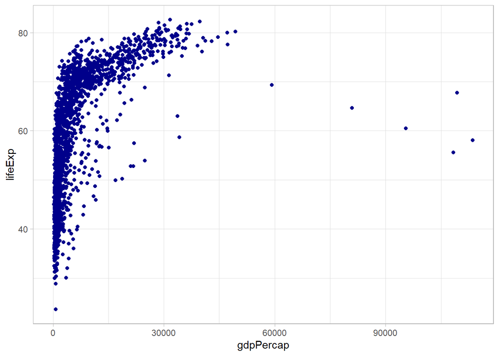

```r
p <- ggplot(data = gapminder,
            mapping = aes(x=gdpPercap,
                          y= lifeExp))
p +
  geom_point(color = "darkblue") +
  theme_light()
```

## 2.2 Linha de tendência

Note que essa visualização nos dá os pontos presentes no gráfico, no entanto, qual a linha de tendência desses pontos?

Para isso utilizaremos a função geom_smooth

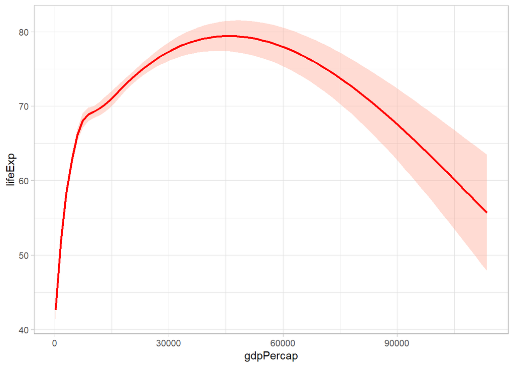

```r
p +
  geom_smooth(color = "red",
                fill = "#ffa590") +
  theme_light()
```

## 2.3 Combinando gráfico e linha de tendência

Podemos plotar os dois dados juntos:

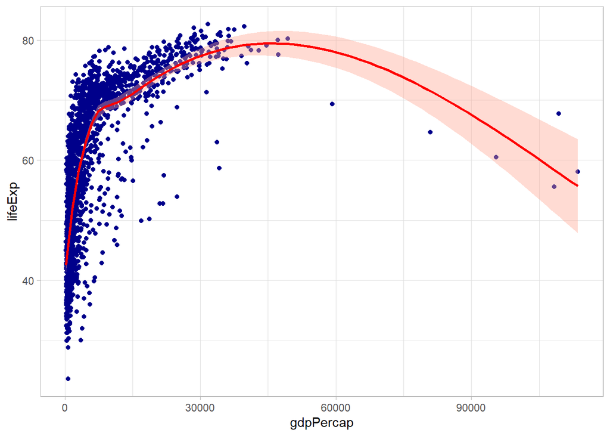

```r
p +
  geom_point() +
  geom_point(color = "darkblue") +
  geom_smooth(color = "red",
              fill = "#ffa590") +
  theme_light()
```

Note no entanto que essa linha não tem um formato muito bem definido, vamos então tentar aplicar a reta que melhor se encaixa nos pontos apresentas, colocando o argumento “lm” na função apresentada.

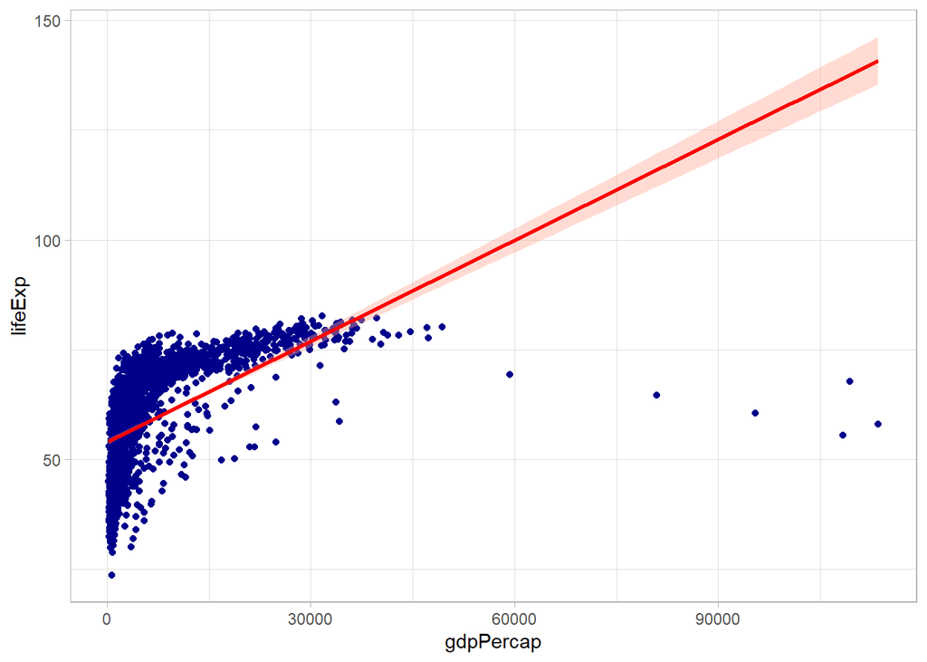

```r
p + geom_point() +
  geom_point(color = "darkblue") +
  geom_smooth(method= lm,
              color = "red",
              fill = "#ffa590") +
  theme_light()
```

Note que claramente nosso modelo não é linear, pois para valores muito grandes, a reta fica muito longe dos dados apresentados. Sendo assim, como podemos melhorar nossa visualização?

# 3 Mudando a escala dos eixos

A resposta é simples, basta notarmos que a riqueza não é dividida igualmente, e que é muito mais comum países com baixos gdp per capita. Sendo assim, vamos deixar nossos dados no eixo x na escala logarítimica.

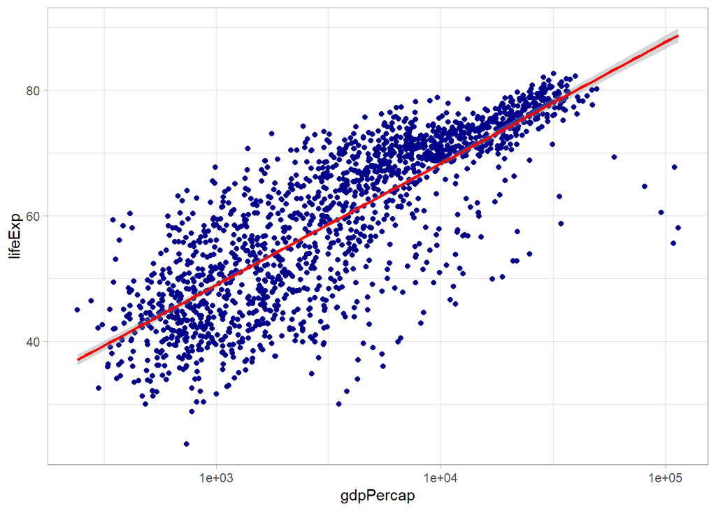

```r
p+
  geom_point(color = "darkblue") +
  geom_smooth(method = "lm",
              color = "red") +
  scale_x_log10() +
  theme_light()
```

Vamos agora deixar a escala com os valores em dólares.

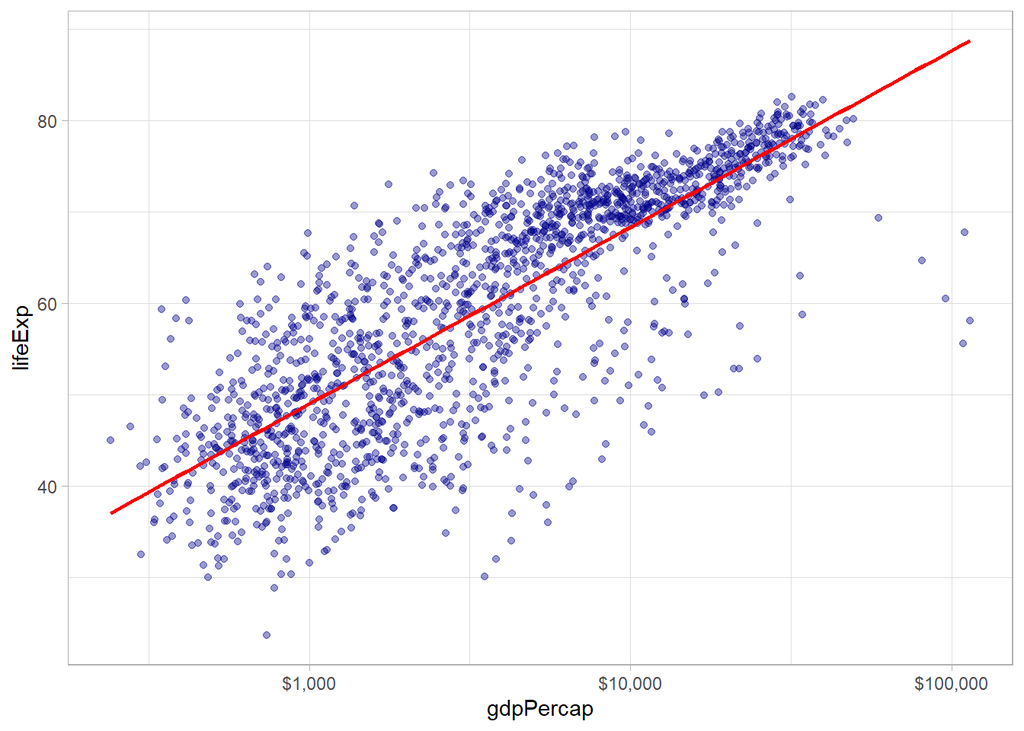

```r
p +
  geom_point(color = "darkblue",
              alpha = 0.4) +
  geom_smooth(method = "lm",
              color = "red",
              se = FALSE) +
  scale_x_log10(labels = scales::dollar) +
  theme_light()
```

# 4 Mudando variáveis dos pontos

Vamos adicionar transparência ao gráfico com a função alpha.

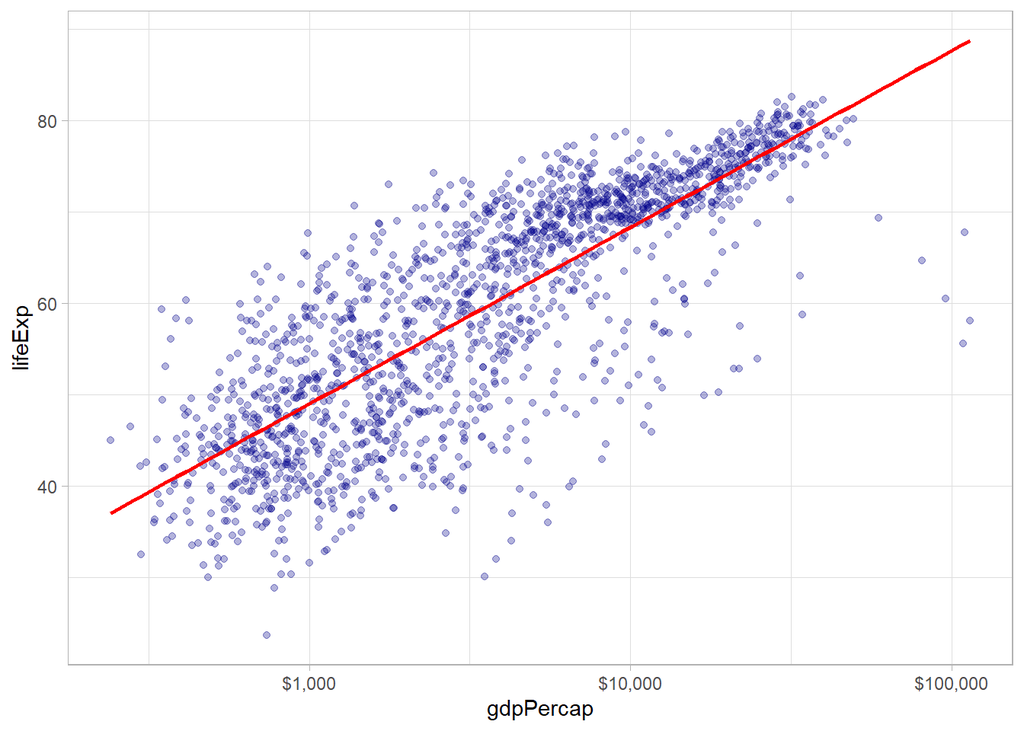

```r
p +
  geom_point(color = "darkblue",
             alpha = 0.3) +
  geom_smooth(color = "red",
              se = FALSE,
              linewidth=1,
              method = lm) +
  scale_x_log10(labels = scales::dollar) +
  theme_light()
```

## 4.1 Overview

O que fizemos foi armezenar as variáveis de onde iremos extrair os dados e os eixos x e y e colocamos todas na variável p. A variável alpha dentro de geom_point, seta o nível de transparência dos dados. Essa escala vai de 0 (invisível) até 1 (totalmente opaco). geom_smooth seta a linha de tendência do gráfico, color define a cor, linewidth a espessura da linha, se=FALSE tira a linha de erro, e method=lm define que o modelo usado para adaptar os dados seráuma reta de regressão. scale_x_log10(labels = scales::dollar), define o eixo x como uma escala log 10 e labels define que a escala deve ser mostrada como valor em dolar.

# 5 Adicionando legendas

Vamos adicionar algumas legendas nesse gráfico, além de um tema para deixá-lo com outra aparência.

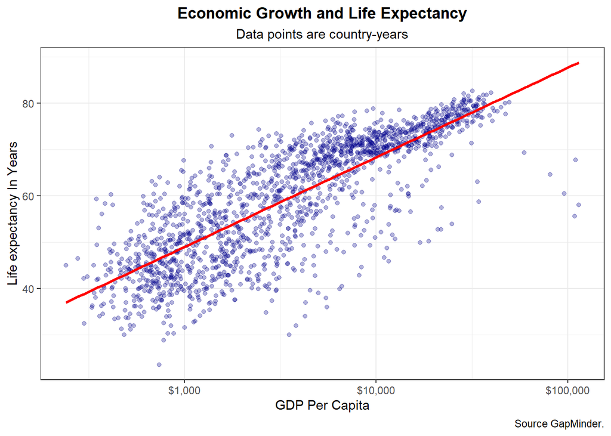

```r
p +
  geom_point(alpha = 0.3, color = "darkblue") +
  geom_smooth( method = "lm", se = FALSE, color = "red") +
  scale_x_log10(labels = scales::dollar) +
  labs(x = "GDP Per Capita",
       y = "Life expectancy In Years",
       title = "Economic Growth and Life Expectancy",
       subtitle = "Data points are country-years",
       caption = "Source GapMinder.") +
  theme_bw() +
  theme(plot.title = element_text(hjust = 0.5, face = "bold"),
        plot.subtitle = element_text(hjust = 0.5))
```

Temos um gráfico relativamente polido, com apenas alguns comandos em R.

# 6 Agrupando os dados

Note que podemos agrupar os dados em conjuntos menores, mas mais parecidos, tais como agrupar os dados pelo continente. Para isso, famos adicionar uma variavel color = continent no aesthetics do ggplot. Vamos adicionar algumas legendas nesse gráfico também.

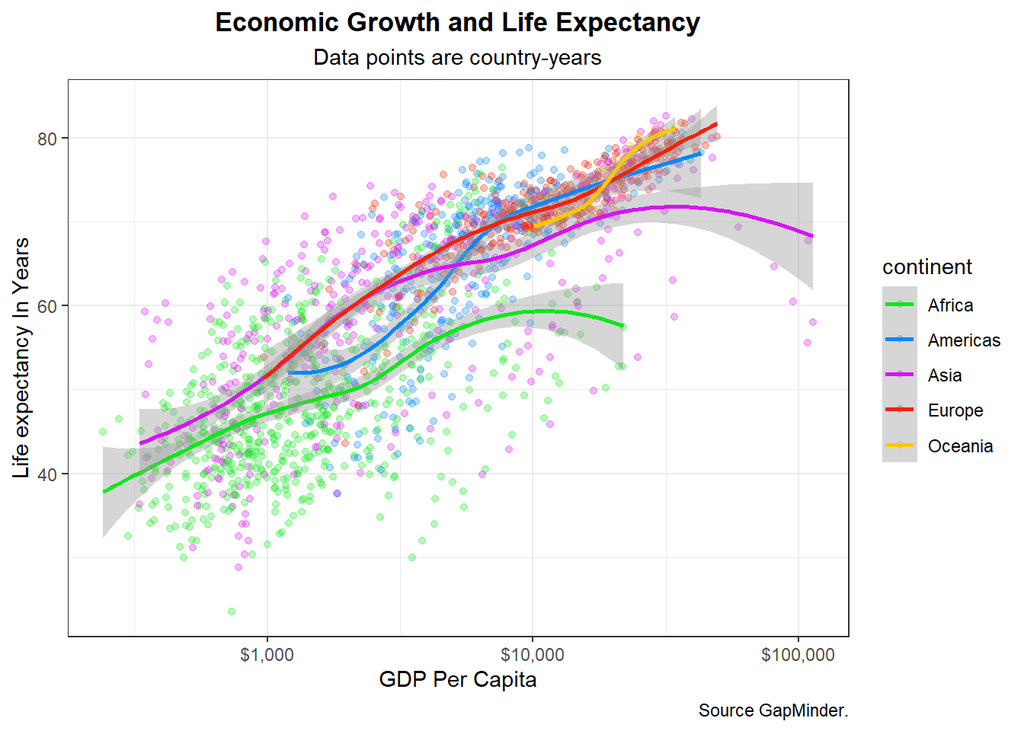

```r
cb_pallete <- c("#10E61B", "#0587FC", "#D813F5", "#F22205", "#FCC705" )

p <- ggplot(data = gapminder, mapping = aes(x=gdpPercap, y=lifeExp, color = continent))

p +
  geom_point(alpha = 0.3) +
  geom_smooth(method = "loess") +
  scale_x_log10(labels = scales::dollar) +
  scale_color_manual(values = cb_pallete) +
  labs(x = "GDP Per Capita", y = "Life expectancy In Years",
       title = "Economic Growth and Life Expectancy",
       subtitle = "Data points are country-years",
       caption = "Source GapMinder.") +
  theme_bw() +
  theme(plot.title = element_text(hjust = 0.5, face = "bold"),
        plot.subtitle = element_text(hjust = 0.5))
```

Caso quisessemos colorir a linha de erro, colocaríamos a variável fill no ambiente aesthictics, pois ela controla qual a cor será preenchida a barra de erro.

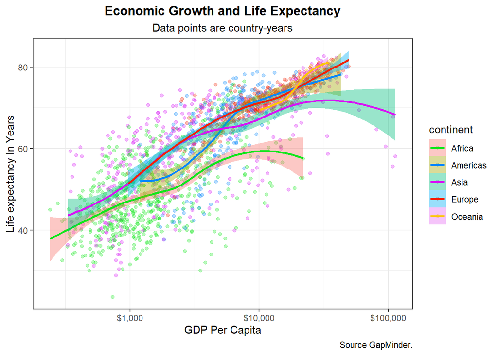

```r
p <- ggplot(data = gapminder,
            mapping = aes(x=gdpPercap,
                          y= lifeExp,
                          color = continent,
                          fill = continent))

p +
  geom_point(alpha = 0.3) +
  geom_smooth( method = "loess") +
  scale_x_log10(labels = scales::dollar) +
  labs(x = "GDP Per Capita",
       y = "Life expectancy In Years",
       title = "Economic Growth and Life Expectancy",
       subtitle = "Data points are country-years",
       caption = "Source GapMinder.") +
  scale_color_manual(values = cb_pallete) +
  theme_bw()+
  theme(plot.title = element_text(hjust = 0.5, face = "bold"),
        plot.subtitle = element_text(hjust = 0.5)) +
  scale_color_manual(values = cb_pallete)
```

Note agora que todas as linhas tem suas linhas e barras de erro. No entanto, vemos que isso deixa o gráfico meio poluido, algo que não queremos. Como podemos fazer para plotar apenas uma linha de erro, mas manter as cores diferentes para cada conjunto de dados?

#deixando o gráfico menos poluído A reposta é simples: basta definir a variável mapping pela função geom_point. Caso definissemos pela função aes() essa os dados seriam carregados por todo o “código” para plotar o gráfico. No entanto, quando definimos pela função geom_point, ela só vai carragar esses dados na hora que estiver criando os pontos, e quando aplicarmos a função geom_smooth, essa variável não vai ser carregada. O código ficaria assim:

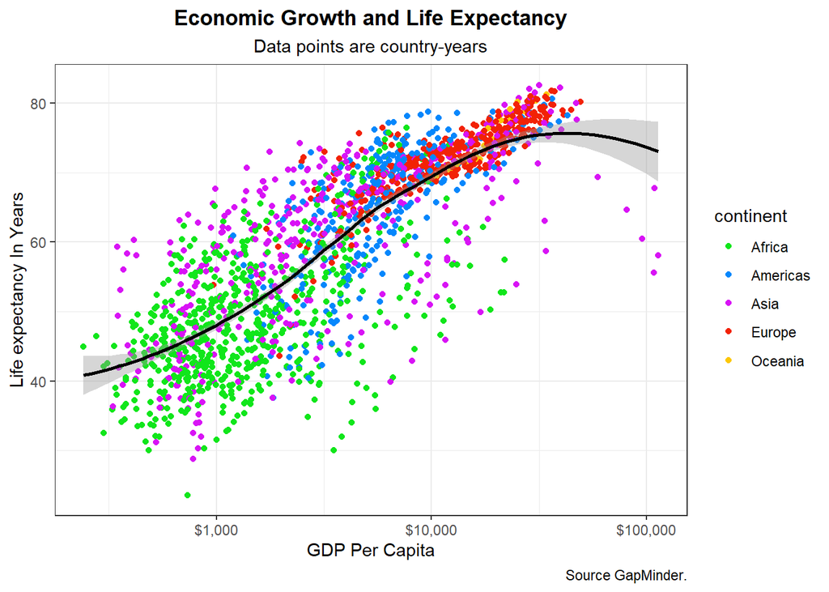

```r
p <- ggplot(data = gapminder,
            mapping = aes(x=gdpPercap,
                          y= lifeExp))
p +
  geom_point(mapping = aes(color = continent,
                           fill = continent)) +
  geom_smooth( method = "loess",
               color = "black") +
  scale_x_log10(labels = scales::dollar) +
  labs(x = "GDP Per Capita",
       y = "Life expectancy In Years",
       title = "Economic Growth and Life Expectancy",
       subtitle = "Data points are country-years",
       caption = "Source GapMinder.") +
  theme_bw()+
  theme(plot.title = element_text(hjust = 0.5, face = "bold"),
        plot.subtitle = element_text(hjust = 0.5)) +
  scale_color_manual(values = cb_pallete)
```

# 7 Adicionando gradientes

Podemos ter também um gradiente logarítimico, apenas adicionando uma variável log na hora de mapear o geom_point. Podemos ver isso por exemplo, adicionando uma variável de cor no geom_point para o log da população.

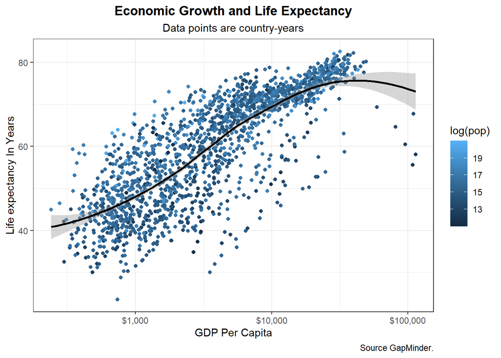

```r
p <- ggplot(data = gapminder,
            mapping = aes(x=gdpPercap,
                          y= lifeExp))
p +
  geom_point(mapping = aes(color = log(pop))) +
  geom_smooth( method = "loess",
               color = "black") +
  scale_x_log10(labels = scales::dollar) +
  labs(x = "GDP Per Capita",
       y = "Life expectancy In Years",
       title = "Economic Growth and Life Expectancy",
       subtitle = "Data points are country-years",
       caption = "Source GapMinder.") +
  theme_bw() +
  theme(plot.title = element_text(hjust = 0.5, face = "bold"),
        plot.subtitle = element_text(hjust = 0.5))
```

Desse modo, vemos como o R pode ser diverso, e como podemos personalizar esse ambiente para realizar os gráficos dos mais variados tipos.